# Revista ECYS - Edición XXIX

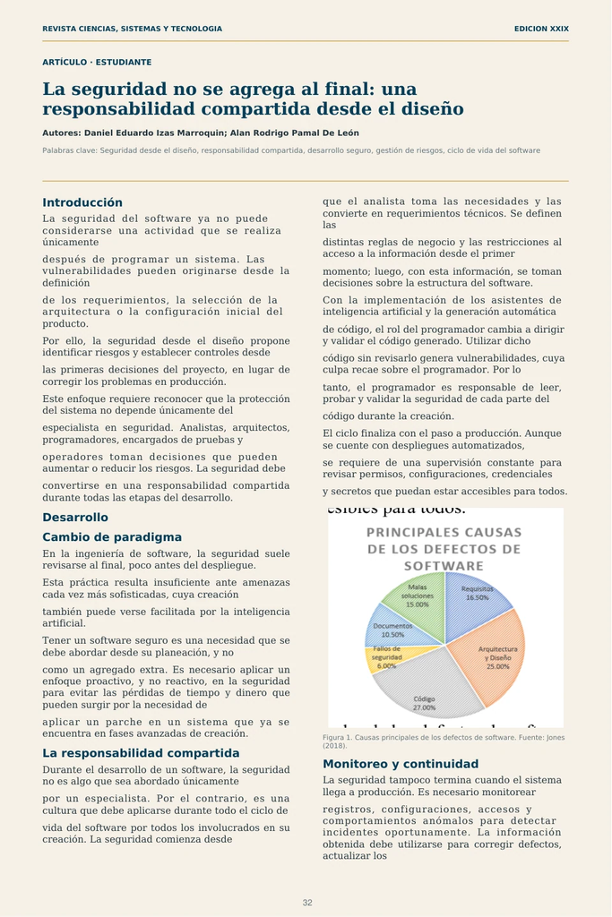

Página 32 de 52

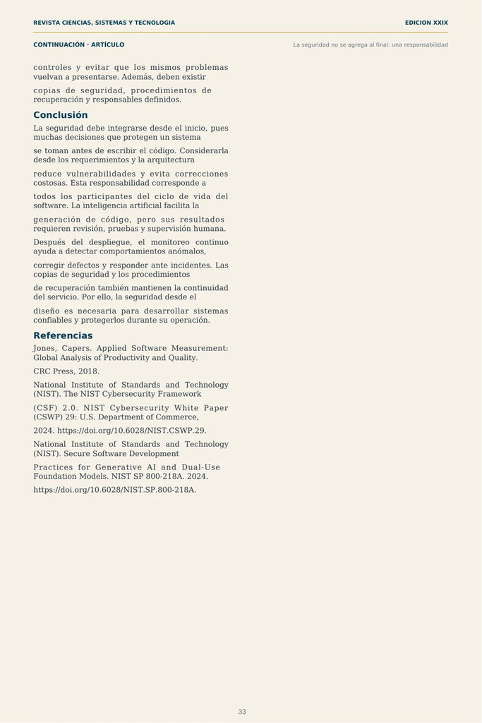

Página 33 de 52

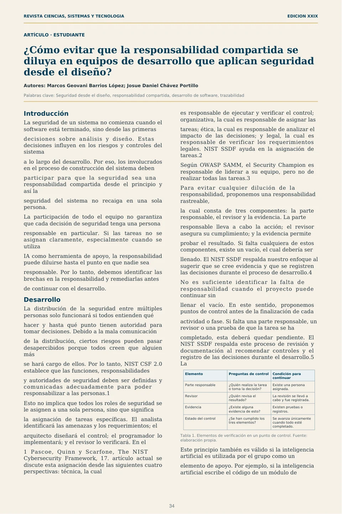

Página 34 de 52

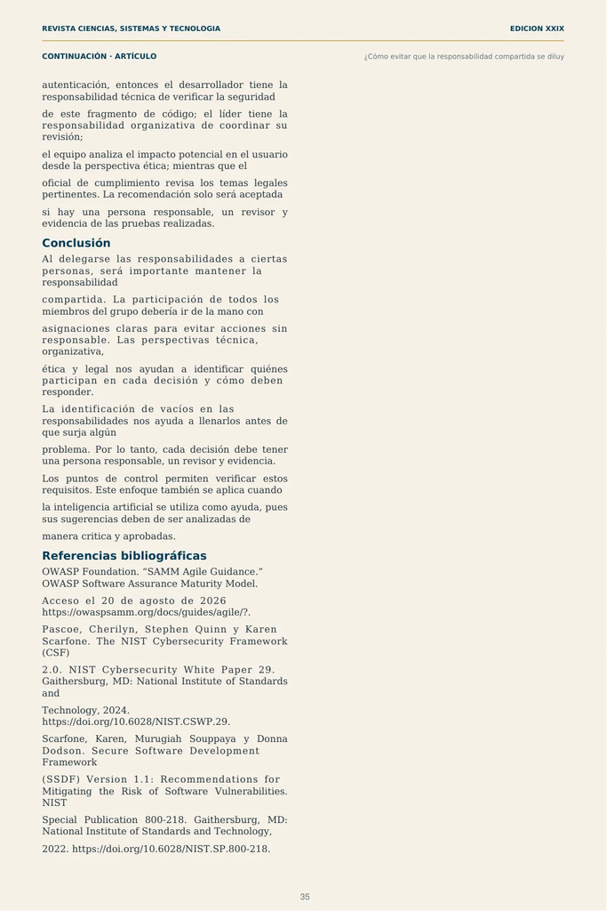

Página 35 de 52

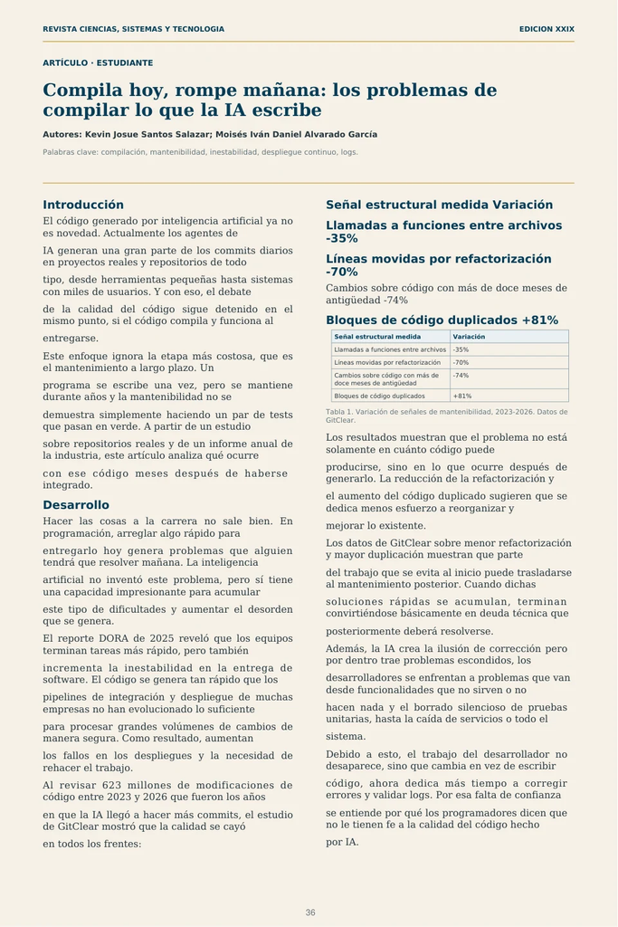

Página 36 de 52

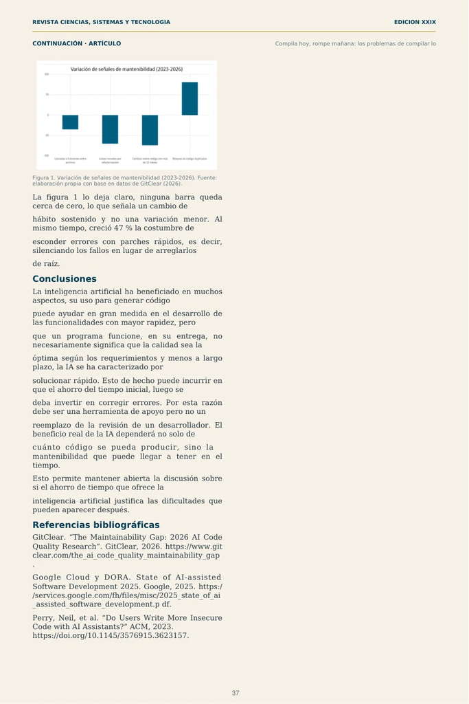

Página 37 de 52

[figure not shown]

Página 38 de 52

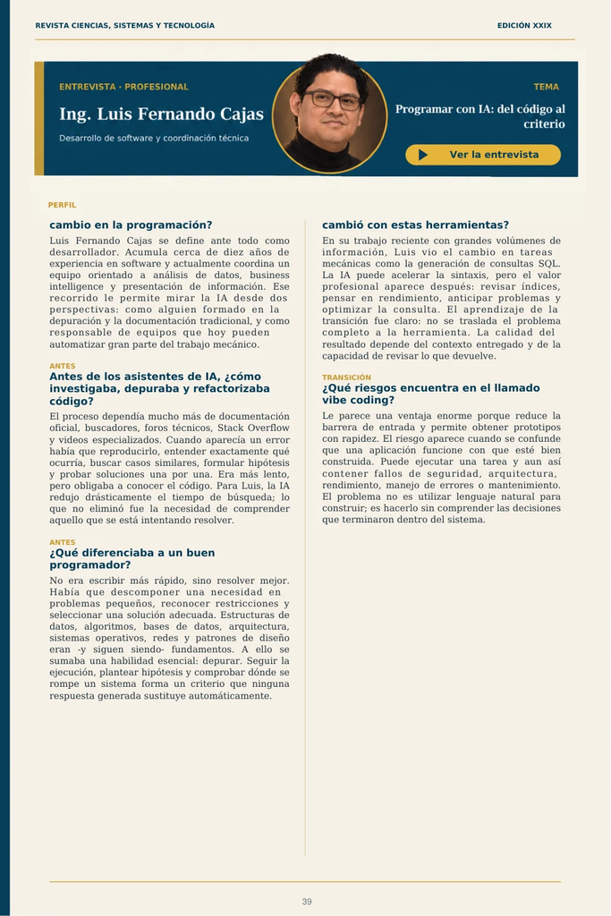

Página 39 de 52

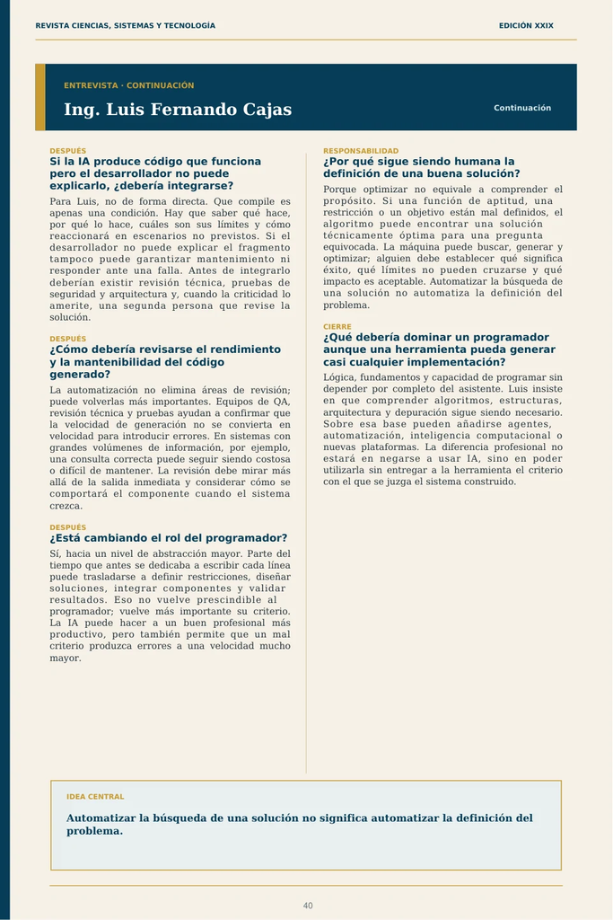

Página 40 de 52

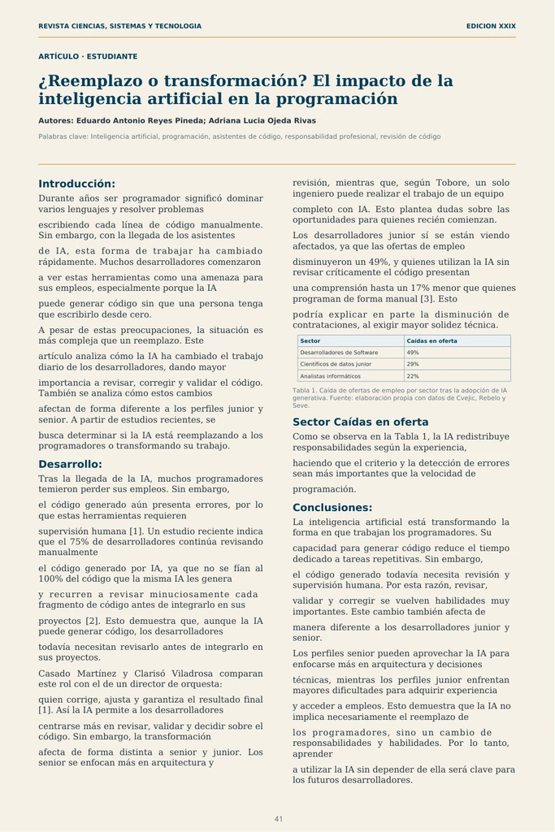

Página 41 de 52

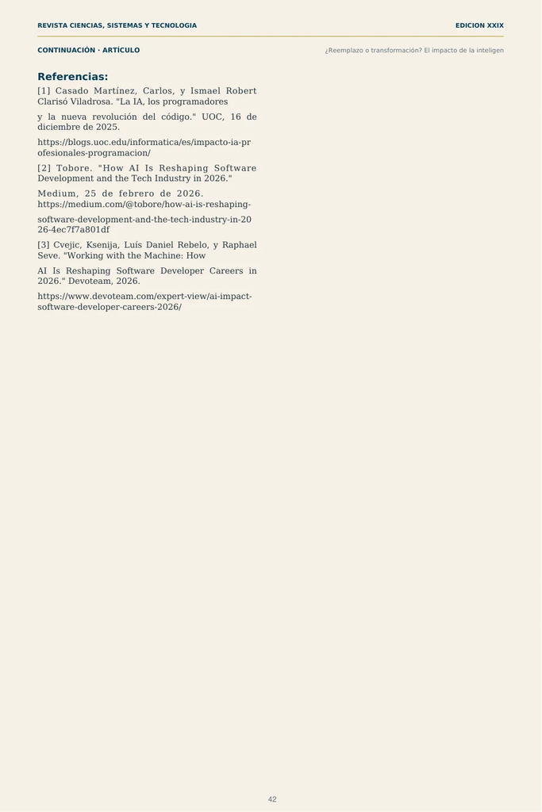

Página 42 de 52

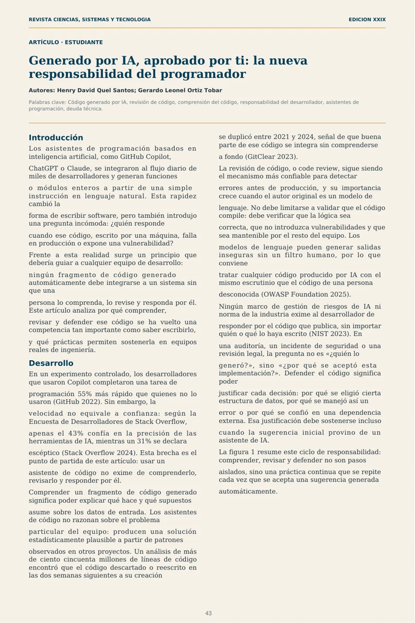

Página 43 de 52

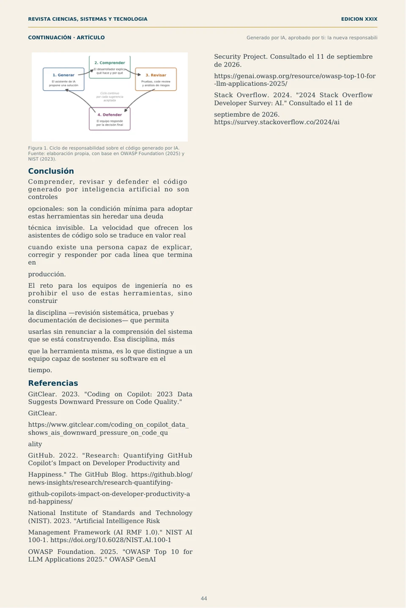

Página 44 de 52

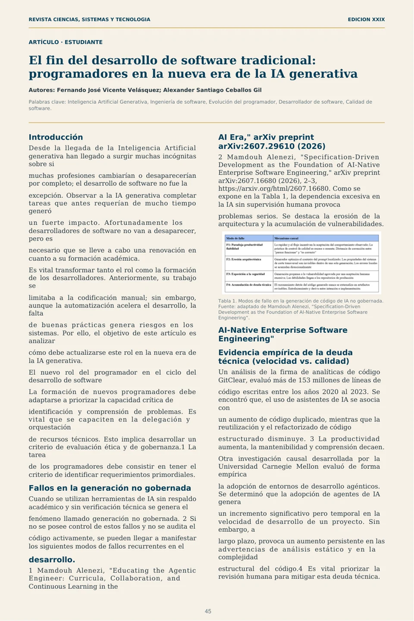

Página 45 de 52

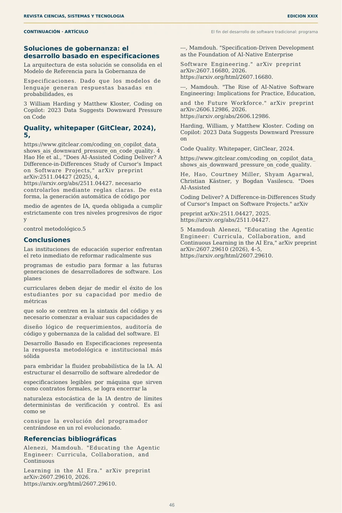

Página 46 de 52

[figure not shown]

Página 47 de 52

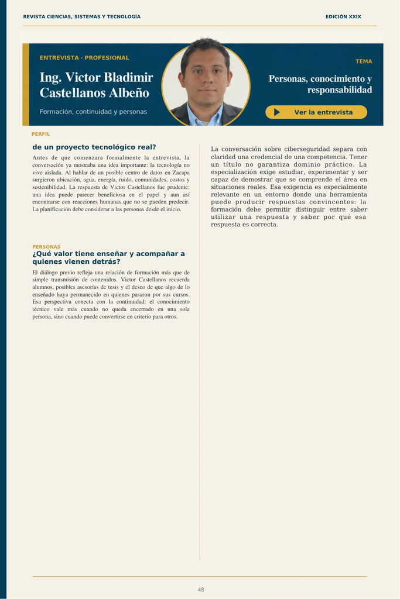

Página 48 de 52

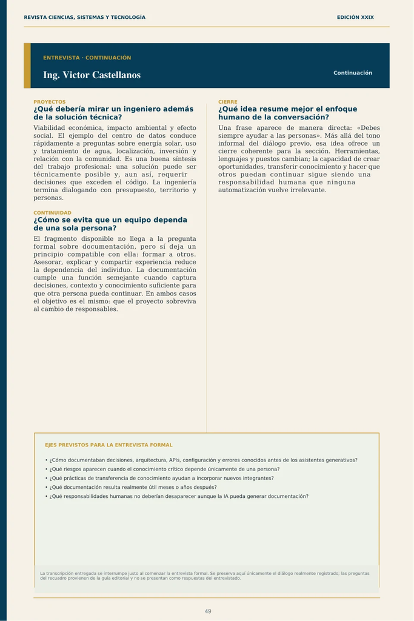

Página 49 de 52

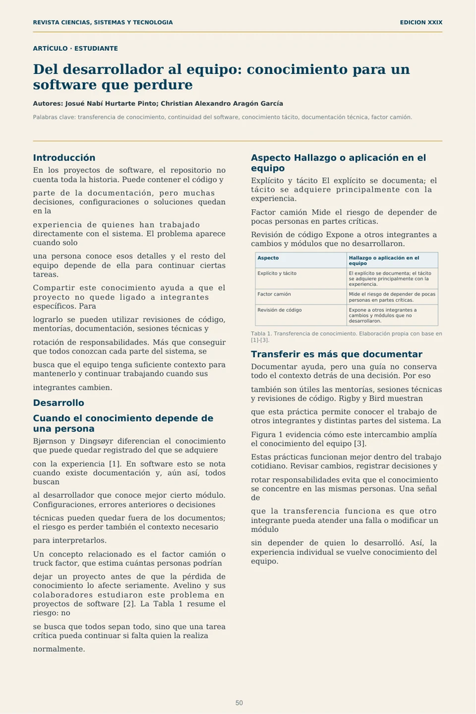

Página 50 de 52

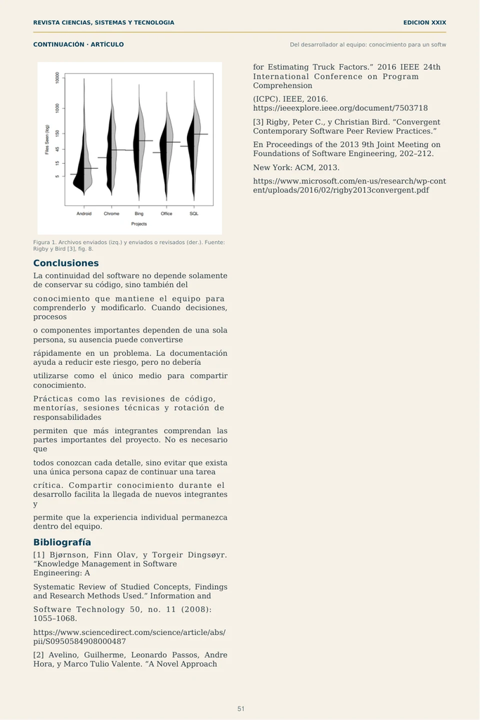

Página 51 de 52

[figure not shown]

Página 52 de 52